# Introduction to statistics

author: Alejandro Cáceres date:  
autosize: true

Barcelona East School of Engineering  
Universitat Politecnica de Catalunya (UPC)

Lecture 6

# Objective

- Sample mean distributions
- Sample variance distribution
- Central limit theorem

# Sample mean distributions

- Probability motivated by the difference in observations we obtain each time we run a random experiment.
- Mass and density probability distributions define the probability of one outcome.
- Probability models define likely probabilities for natural/engineered phenomena. We have assumed **we know** the parameters of the models and can then compute probabilities.

# Sample mean distributions

What do we do in real life?

- We perform one random experiment many times.

Imagine your company is asked to sell metallic cables for the port of Barcelona that can carry up to 12 Tons.

- You have on **stock** one type of cable that could do the job but they have never been used to carry more than 10 tons.

Can you use the cables in stock or you need to produce another one?

# Sample mean distributions

- If one cable in stock cannot take the load and breaks it can injure workers.

However

- Let’s imagine that testing the resistance of 8 cables in stock is cheaper than producing a new product.
- You save money on design and manufacturing. Even if you manufactured a new product you still have to run tests.

# Sample mean distributions

You convince the company to invest in testing loading each cable until braking. Here are the results

```r
x1=13.34642, x2=13.32620, x3=13.01459, x4=13.10811, x5=12.96999, x6=13.55309, x7=13.75557, x8=12.62747
```

# Sample mean distributions

let’s plot them

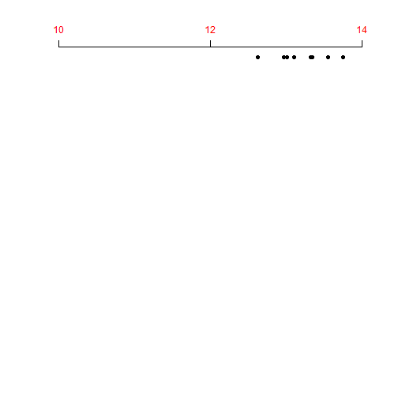

# Sample mean distributions

- None of them broke at 12 Tons.
- How sure are we that the one we sell does not break at 12 Tones?
- There was one that broke at 12.62747 Tons.

Do you take the risk?

# Sample mean distributions

- In real life we repeat and experiment $n$ times and don’t know the probability distribution of the outcomes or its parameters.
- Let’s assume that the load at which cables brake follows a normal distribution ($N(\mu, \sigma^2)$).
- We do not know what $\mu$ and $\sigma^2$ are.

So we **estimate** them from data.

# Sample mean distributions

- The average is defined as

$\bar{x}=\frac{1}{N} \sum_{j=1..N} x_j$

where $x_j$ is the **observation** $j$ from a total of $N$.

In terms of the **outcomes** that categorical variables can take

$\bar{x}= \sum_{i=1..m} x_i \frac{n_i}{N}=\sum_{i=1..m} x_i f_i$

where $x_i$ is the **outcome** $i$ from a total of $m$. If the numner of observations is infinite, then we **should** have

$\bar{x} \rightarrow \sum_{i=1..m} x_i P(X=x_i)= \sum_{i=1..m} x f(x_i)= E(X)$.

- $f_i$ are relative frequencies (data)
- $f(x_i)$ are probabilities (model)

# Sample mean distributions

- $\bar{x}$ is one the result of averaging the repetition of $n$- independent experiments.

The repetition of an experiment $n$ times is called an $n$-sample.

Remember the repetition of $n$-Bernoulli trials and counting the number of events?

That is a Binomial experiment: A random experiment composed of $n$ random experiment.

- If we performed another $n$-sample then we would get another result for $\bar{x}$.

$\bar{x}$ is the observation of one random experiment: sampling $X$ $n$-times!

# Sample mean distributions

**Definition**

The sample mean (or average) of a **random sample** of size $n$ is defined as

$\bar{X}=\frac{1}{n}\Sigma_{i=1}^n X_i$

Our experiment with cables in stock results in the realization of this random variable

$\bar{X}=\bar{x}_{stock}=13.21Tons$

# Sample distributions functions

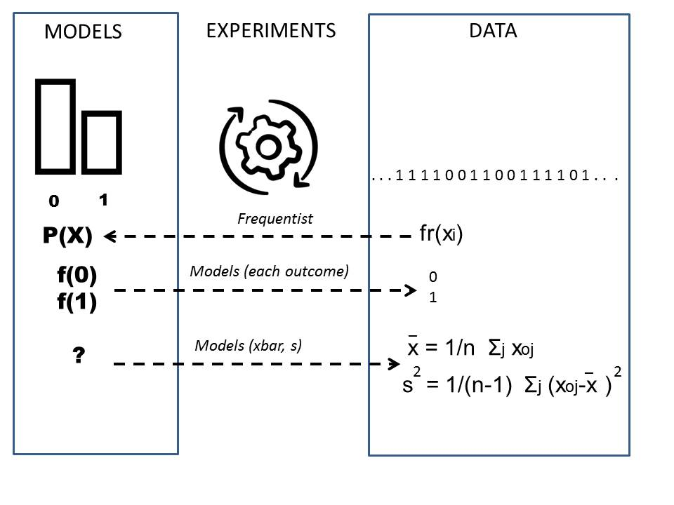

# Sample mean distributions

There are two distributions:

- The population distribution: the same for each random variable $X_i$ of each random experiment.

$f_x(x)dx=P(x\leq X\leq x+dx)$

$E(X_i)=E(X)=\mu$ and $V(X_i)=V(X)=\sigma^2$

- The distribution of $\bar{X}$, that it the sample mean distribution

$f_{\bar{x}}(\bar{x})d\bar{x}=P(\bar{x}\leq \bar{X}\leq \bar{x}+d\bar{x})$

$E(\bar{X})=\mu_{\bar{X}}$ and $V(\bar{X})=\sigma_{\bar{X}}^2$

# Sample mean distributions

What are $\mu_{\bar{X}}$ and $\sigma^2_{\bar{X}}$, in terms of $\mu$ and $\sigma^2$?

$E(\bar{X})=\mu_{\bar{X}}=E(\frac{1}{n}\Sigma_{i=1}^n X_i)$

$=\frac{1}{n} \Sigma_{i=1}^n (X_i)$

$=\frac{1}{n} \Sigma_{i=1}^n \mu$

$=\mu$

This makes sense:

$\mu_{\bar{X}}$ the expectation of the average is the expectation of a single experiment. This allows us to use $\bar{x}$ to **estimate** $\mu$.

# Sample mean distributions

What is the variance of the average $\bar{X}$?

$V(\bar{X})=\sigma^2_{\bar{X}}=V(\frac{1}{n}\sum_{i=1}^n X_i)=\frac{1}{n^2} V(\sum_{i=1}^n X_i)$

$= \frac{1}{n^2} \sum_{i=1}^n \sigma^2=\frac{1}{n^2} n \sigma^2$

$= \frac{\sigma^2}{n}$

This is an important general result!

The second line

$V(\sum_{i=1}^n X_i)=\sum_{i=1}^nV(X_i)$

follows for the independence of $n$ random variables -we are not showing

# Sample mean distributions

$V(\bar{X})= \frac{\sigma^2}{n}$  
As $n\rightarrow \infty$ then $\sigma^2_{\bar{X}}\rightarrow 0$

- The more repetitions we have of the experiment, the less disperse the average $\bar{X}$ is.
- This is fully consistent with the frequentist interpretation of probabilities: the more we repeat the experiment the closer we get to the probabilities of the outcomes; in our case precise knowledge of $\mu$.
- We have to repeat an experiment as much as possible!

# Sample mean distributions

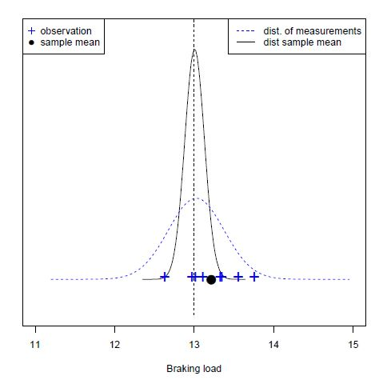

# Sample mean distributions

Before we can use data to learn about the distributions, we are going to remain in the model (abstract) space and first answer the question:

How does the distribution of $X$, $f_x(x)$, determines the distribution of $\bar{X}$, $f(\bar{x})$?

This question is important because if we want to use the observed value $\bar{x}$ of an $n$-sample experiment to **estimate** $\mu_X$, we need to know how $\bar{X}$ distributes so we can compute probabilities of $\bar{X}$ it-self.

# Sample mean distributions

How is the distribution of $\bar{X}$ when $X$ comes from

- A Bernoulli trial
- A normal distribution
- Any distribution but large $n$

# Sample mean distributions: Bernoulli trials

The probability mass function of a Bernoulli random variable $X$ with values $x \in {0,1}$ defined by $A\rightarrow x=1$ and $B\rightarrow x=0$

$f(x)=(1-p)^{1-x} p^x$

- $p$ is the probability of $A$ and the parameter of the distribution
- $E(X)=p$
- $V(X)=p(1-p)$

# Sample mean distributions: Bernoulli trials

For a random sample $X_1, ...X_n$ of $n$ Bernoulli trials the random variable

$Y=\sum_{i=1}^n X_i$

distributes binominaly  
$Y \hookrightarrow Bin(p,n)$ and $P(Y=i)=f(i)=\binom n y (1-p)^{n-y}p^y$ for $y=0,1,...n$

Remember

- $E(Y)=np$
- $V(Y)=np(1-p)$

# Sample mean distributions: Bernoulli trials

The sample mean $\bar{X}$ is simply

$\bar{X}=\frac{Y}{n}=\frac{1}{n}\sum_{i=1}^n X_i$

Then, the mean of $\bar{X}$ is

$E(\bar{X})=E(\frac{Y}{n})= \frac{np}{n}=p$  
$E(\bar{X})=E(X)=p$

Since the expected value of $\bar{X}$ is $p$

$E(\bar{X})=E(X)=p$

we say that is $\bar{X}$ is and **unbiased** estimator of $p$.

# Sample mean distributions: Bernoulli trials

The variance of $\bar{X}$

$V(\bar{X})=V(\frac{Y}{n})= \frac{1}{n^2}V(Y)$  
$=\frac{p(1-p)}{n}$  
$=\frac{V(X)}{n}$

or in $\sigma$-notation, we recover the **general** result  
$\sigma^2_{\bar{X}}=\frac{\sigma^2_X}{n}$

$\sigma^2_{\bar{X}}\rightarrow 0$, $n \rightarrow \infty$

The value of $\bar{X}$ are centerd about $p$ and they disperse very little when $n$ is big.

We can take one single observation of $\bar{x}$ as an approximate value for $p$.

# Sample mean distributions: Bernoulli trials

Now, we have finally built a mathematical tool that accounts for the empirical observation of probabilities.

- When we toss a coin many times $n\rightarrow \infty$ we have a mathematical **justification** to take the average of how many heads we **observed** $\bar{x}$ to estimate the probability of heads $p$.

Because:

- the number that we obtain $\bar{x}$ is one realization of the random variable $\bar{X}$ that has expectation $E(\bar{X})=p$.
- while the number $\bar{x}$ is not $p$ it concentrates around it as we increase $n$: $V(\bar{X})=\frac{1}{n}V(X) \rightarrow 0$ when $n \rightarrow \infty$

# Sample mean distributions: Bernoulli trials

$\lim_{n\rightarrow \infty} \bar{x} = \lim_{n\rightarrow \infty} \frac{n_{heads}}{n} = P_{heads}=p$

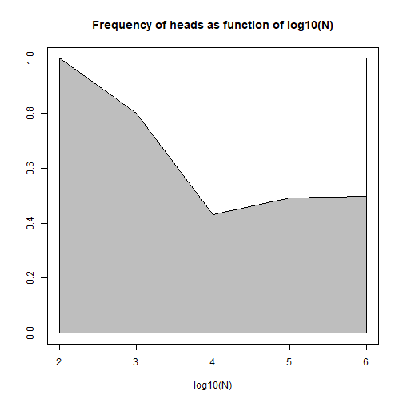

# Sample mean distributions

How is the distribution of $\bar{X}$ when $X$ comes from

- A Bernoulli trial
- A normal distribution
- Any distribution but large $n$

# Sample mean distributions: Normal

If $X$ is a continuous random variable with normal distribution  
$X \rightarrow N(\mu_X, \sigma_X^2)$ with **parameters**: $\mu_X$ and $\sigma_X$.

The mean and variance of $X$ are: $E(X)=\mu$, $V(X)=\sigma^2$

- For a random sample $X_1, ...X_n$ of $n$ normal random variables, $X_i \hookrightarrow N(\mu_X, \sigma_X^2)$, we define again the sample mean random variable

$\bar{X}=\frac{1}{n}\sum_{i=1}^n X_i$.

How is the distribution of $\bar{X}$?

# Sample mean distributions: Normal

Imagine we **know** exactly how $X$ distributes; that is $X \rightarrow N(\mu_X, \sigma_X^2)$ and we know exactly what the values of $\mu_X$ and the variance $\sigma_X$ are

we can then show that

$\bar{X}\rightarrow N(\mu_X, \frac{\sigma_X^2}{n})$

We had already showed that in the general case

$E(\bar{X})=E(X)=\mu_X$

and

$V(\bar{X})=\frac{V(X)}{n}=\frac{\sigma_X^2}{n}$.

The tricky part is to show that the **sum** of independent **normal** variables is also a normal random variable.

# Sample mean distributions: Normal

**Theoretical note**

Moment generating function

We used the moment generating functio $M_x$, defined as:

$M_X(t)=E(e^{tX})=\int_{-\infty}^{\infty} e^{tx} f(x)dx$

to produce the moments by a simple differentiation:

$\mu'_r =\frac{d^r M_X(t)}{dt^r}\bigm|_{t=0}$

We use the moment generating function of the normal distribution to show that the sum of independent normally distributed variables is normal.

# Sample mean distributions: Normal

**Theoretical note**

Sketch of the prof (additional material):

- The moment generating function for a standard distribution $N(\mu,\sigma^2)$ can be obtained by integration:

$M_{X}(t)=\int_{-\infty}^{\infty} e^{tx} \frac{1}{\sqrt{2\pi}\sigma}e^{-\frac{(x-\mu)^2}{2\sigma}}dx=e^{t\mu+\frac{1}{2}\sigma^2t^2}$

- for $X_1, .... X_n$ random independet variables we have

$df(x_1,x_2,..,x_n)=f(x_1)f(x_2)..f(x_n)dx_1..dx_n$

The moment generating function for $\sum_i X_i$ is then

$M_{\sum_i X_i}(t)=E(e^{t\sum_i x_i})=\int_{-\infty}^{\infty} e^{t(x_1+..+x_n)} f(x_1)..f(x_n)dx_1..dx_n$

$=\Pi_{i=1}^{n} M_{X_i}(t)=\Pi_{i=1}^{n} e^{t\mu+\frac{1}{2}\sigma^2t^2}$

$= e^{\sum_i t\mu+\sum_i \frac{1}{2}\sigma^2t^2}= e^{nt\mu+\frac{1}{2}(n\sigma^2) t^2 }$

this is the moment generation function of a normal distribution  
$\sum_{i=1}^n x_i \hookrightarrow N(n\mu, n\sigma^2)$

# Sample mean distributions: Normal

- The sum $\sum_{i=1}^n X_i$ of $n$ random normally distributed variables $X_1$,…$X_n$ all with mean $\mu_X$ and variance $\sigma^2_X$ is a normal distribution:

$\sum_{i=1}^n X_i \hookrightarrow N(n*\mu_X, n*\sigma_X^2)$

with

- mean: $E(\sum_{i=1}^n X_i)=n*\mu_X$
- variance: $V(\sum_{i=1}^n X_i)=n*\sigma_X$

# Sample mean distributions: Normal

- Since the sample mean is $\bar{X}=\frac{1}{n}\sum_{i=1}^n X_i$ then

$\bar{X}\hookrightarrow N(\mu_X, \frac{\sigma_X^2}{n})$,

with

- mean: $E(\bar{X})=\frac{n}{n}E(X)=\mu_X$
- variance: $V(\bar{X})=nV(\frac{1}{n}\sum_{i=1}^n X_i)=\frac{n}{n^2}\sigma^2_X=\frac{\sigma^2_X}{n}$

# Sample mean distributions: Normal

Imagine we **knew** that our cables’ braking load distributes normally with a mean of $13.21$ Tons and a standard deviation of $0.35$.

- What is the probability that one cable breaks at $12$ Tons?

The population mean is $\mu_X=13.21$ and the standard deviation is $\sigma_X=0.35$

We want to compute $P(X\leq 12)$

$P(X\leq12 T)=P(\frac{X-\mu_X}{\sigma_X} \leq \frac{12-\mu_X}{\sigma_X})$

Let’s standardize

$P(Z \leq \frac{12-\mu_X}{\sigma_X})=\Phi(\frac{12-\mu_X}{\sigma_X})$,

where $\Phi$ is the cumulative probability function for the standard distribution, as $Z \hookrightarrow N(0,1)$.

`pnorm(-3.45)=0.0002`.

# Sample mean distributions: Normal

Using tables

- $\Phi(2.15)=0.98422$
- $\Phi(-2.15)=1-0.98422=0.01578$

In our example $\Phi(-3.45)=1-\Phi(3.45)\sim 0$

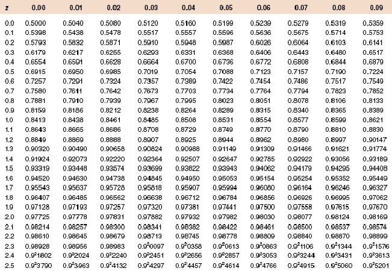

# Sample mean distributions: Normal

For the sample mean

- What is the probability that the 8-sample mean is lower than 12 Tons?

The **sample** mean is $E(\bar{X})=13.21$

and its the standard deviation is

$\sigma_\bar{X}=\sigma_X/\sqrt{n}=0.35/\sqrt{8}=0.12$

We want to compute $P(\bar{X}\leq 12)$

$P(\bar{X}\leq12 T)=P(\frac{X-\mu_\bar{X}}{\sigma_\bar{X}} \leq \frac{12-\mu_\bar{X}}{\sigma_\bar{X}})=P(Z \leq \frac{12-\mu_\bar{X}}{\sigma_\bar{X}})$

Since $\bar{X}$ distributes normally then $Z$ follows a standard distribution and

$P(Z \leq \frac{12-\mu_\bar{X}}{\sigma_\bar{X}})=\Phi(-10.08)\sim 0$

`pnorm(-10.08)=3.38e-24`.

If we repeat the experiment with another 8 samples it is almost imposible tha we ontain an average that is less than $12$ Tons!

# Sample mean distributions: Normal

However, what if they want to use the 8 cables to carry 8*12=96 tons. What is the probability that the 8 cables can carry that load?

We want to compute $P(Y\leq 12)$

$P(Y\leq 96 T)=P(\frac{Y-\mu_Y}{\sigma_Y} \leq \frac{96-\mu_Y}{\sigma_Y})=P(Z \leq \frac{96-\mu_Y}{\sigma_Y})=P(Z \leq \frac{8\cdot 12-8\cdot 13.21 }{8\cdot 0.35})$

and because $Y$ also distributes normally then

$\Phi(-3.45) = 0.0002$

which is the result for a single cable!

# Exercise

Les alçades de 10000 estudiants tenen una distribució aproximadament normal de mitjana $\mu = 174.5 cm$ i desviació típica $\sigma = 6.9 cm$. Considereu una mostra aleatòria simple de $25$ estudiants

$X_1,X_2,...,X_{25}$

i la seva mitjana mostral

$\bar{X} = \frac{1}{25} \sum_{i=1}^{25} X_i$

1. Calculeu l’esperança i la desviació típica de la mitjana mostral.
2. Calculeu la probabilitat que la mitjana mostral sigui inferior a 173.
3. Considereu ara un conjunt de 200 mostres aleatòries de 25 estudiants cadascuna. Sigui $\bar{X}_1$ la mitjana mostral de la primera mostra, $\bar{X}_2$ la mitjana mostral de la segona mostra, i així successivament. Sigui ara Y la variable aleatòria discreta que mesura quantes d’aquestes mitjanes mostrals són inferiors a 173. Quin és el valor esperat de mitjanes mostrals que seran inferiors a 173?
4. Quina hauria de ser la mida de la mostra perquè el valor esperat de mitjanes mostrals que són inferiors a 173 sigui 9?

Nota: en (d) piensa en usar $\Phi^{-1}(x)$ que en R se calcula con la funcion `qnomr(x)`

# Sample mean distributions

How is the distribution of $\bar{X}$ when $X$ comes from

- A Bernoulli trial
- A normal distribution
- Any distribution but large $n$

# Sample mean distributions: Large n

- Let’s relax the condition that the random variable $X$, from which the n-sample is taken, is normal.
- Instead, imagine that we take many samples $n\rightarrow \infty$

Under this condition how does $\bar{X}$ distributes?

# Sample mean distributions: Large n

**Central Limit Theorem (CLT)** (we won’t prove*)

For a random sample $X_1,...X_2$ on a population distribution of the variable $X$ with mean $\mu_X$ and variance $\sigma_X^2$ then the standardized variable of $\bar{X}$ given by

$Z=\frac{\bar{X}-E(\bar{X})}{\sqrt{V(\bar{X})}}=\frac{\bar{X}-\mu_X}{\sigma_X/\sqrt{n}}$ follows a standard distribution; that is

$Z\hookrightarrow N(0,1)$,

when $n\rightarrow \infty$

(*a prove using moment generating functions can be found in Freund’s Mathematical Statistics with applications)

# Sample mean distributions: CLT

The central limit theorem:

$Z=\frac{\bar{X}-\mu_X}{\sigma_X/\sqrt{n}} \rightarrow N(0,1)$ when $n\rightarrow \infty$

Justifies the approximation of

- $\bar{X}\sim N(\mu_X, \frac{\sigma_X^2}{n})$

and of

- $Y=\sum_i X_i = n \cdot \bar{X} \sim N(n \cdot \mu_X, n \cdot \sigma_X^2)$

when $n >30$

Note: when $n\rightarrow \infty$, $\bar{X} \rightarrow {f(x=\mu_X) =\infty, f(x\neq \mu_X) = 0}$

# Sample mean distributions: CLT

The central limit theorem tells us that:

- the distribution of $\bar{X}$ can be **approximated** by a normal distribution for large values of $n$
- no matter what the population distribution $f_X$ is; that is, how measurements $X_i$ distribute

Note that when $X$ **actually** distributes normally then the distribution of $\bar{X}$ is **exactly normal**, as we previously showed.

# Sample mean distributions: CLT

Let’s see an application of the central limit theorem to the binomial distribution

We are going to show that the Binomial distribution tends to the Normal distribution when the number of Bernoulli trials is large.

Let’s consider

- $X$ a Bernoulli random variable:

$f(x)= (1-p)^{1-x}p^{x}$

with mean $\mu_X=p$ and variance $\sigma^2_X=(1-p)p$

- $Y=\sum_{i=1..n} X_i$ is Binomial

$f(y)=\binom n y p^y(1-p)^{n-y}$ $y=0,1,...n$

that’s is $Y\hookrightarrow Bin(n,p)$

with mean $\mu_X=np$ and variance $\sigma^2_Y=n(1-p)p$

# Sample mean distributions: CLT

Let’s standardize $Y$

$Z=\frac{Y-E(Y)}{\sqrt{V(Y)}}=\frac{Y-np}{\sqrt{np(1-p)}}$

because $E(Y)=np$ and $V(Y)=np(1-p)$

divide by $n$ both the numerator and the denominator $Z=\frac{Y/n-p}{\sqrt{p(1-p)}/\sqrt{n}}$

Now, $Y$ can be written as

$\frac{Y}{n}=\frac{1}{n}\sum_{i=1}^n X_i=\bar{X}$

# Sample mean distributions: CLT

Therefore

$Z=\frac{Y/n-p}{\sqrt{p(1-p)}/\sqrt{n}}$

can be written as

$Z=\frac{\bar{X}-p}{\sqrt{p(1-p)}/\sqrt{n}}=\frac{\bar{X}-\mu_X}{\sigma_X/\sqrt{n}}$

This is clearly the estandardization of the mean $\bar{X}$

$Z=\frac{\bar{X}-\mu_\bar{X}}{\sigma_\bar{X}}$

Therfore, by the CLT

$Z\rightarrow N(0,1)$ when $n\rightarrow \infty$

and the distribution of $\bar{X}$ can be aproximated as

$\bar{X} \sim N(p,p(1-p)/n)$

# Sample mean distributions: CLT

- the distribution of $X$ can **also** be approximated by  
  $X \rightarrow Bin(n,p)\sim N(np,np(1-p))$

because they share the same estandardized statistic $Z$

Therefore we have the approximation of one distribution into another

$Bin(n,p)\sim N(np,np(1-p))$

Which is consider good when $n>30$ and both $np$ and $n(1-p)$ are both greater than $5$.

# Sample variance distribution

Our intention is to take one observed value of $\bar{X}$ (big $X$); that is $\bar{x}$ (litte $x$), as an experimental **estimate** of for $\mu$.

- That is enough when $X$ follows a Bernulli trial distribution, where we have only one parameter $p$, $E(\bar{X})=\mu_\bar{X}=\mu_X=p$
- When $X$ follows a normal distribution we have two parameters $\mu_X$ and $\sigma_X$.

As $E(\bar{X})=\mu_X$, could we also take $V(\bar{X})$ as a mesurement of $\sigma$?

$V(\bar{X})=E[(\bar{X}-\mu)^2]$

But we don’t know $\mu$! and it gives us the dispersion of $\bar{X}$ about the mean not the dispersion of the $x_i$.

# Sample variance distribution

**Definition**

The **sample variance** $S^2$ is the **random variable**, function of the $n$-random sample $X_1, ...X_n$, given by  
$S^2= \frac{1}{n-1}\sum_{i=1}^n (X_i-\bar{X})^2$

- $S^2$ (big $S$) is the random variable and $s^2$ (little $s$) is the **observation** of $S^2$.
- $s^2$ is the **sample** variance and it is computed from **data** (little $x_i$ and $\bar{x}$) as:  
  $s^2= \frac{1}{n-1}\sum_{i=1}^n (x_i-\bar{x})^2$ its square root is the standard deviation of the sample $s$.
- $S^2$ is the average distances of the observations to $\bar{X}$ (except it is divided by n-1). $S$ is known as the **standard error**

# Sample variance distribution

**Theoretical note**

Remember that $\bar{X}$ disperses around $\mu_X$ with variance $\sigma^2_X/n$. To estimate the dispersion of the measurements around $\mu_X$ then we need to correct for the deviation given by $\bar{X}$.

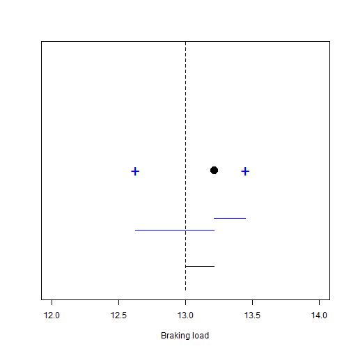

# Sample variance distribution

**Theoretical note**

Let’s compute the expected value of $S^2$

$E(S^2)=E[\frac{1}{n-1}\sum_{i=1}^n (X_i-\bar{X})^2]$

$=\frac{1}{n-1}E[\sum_{i=1}^n \{(X_i-\mu)-(\bar{X}-\mu)\}^2]$

$=\frac{1}{n-1}E[\sum_{i=1}^n \{(X_i-\mu)^2-2(X_i-\mu)(\bar{X}-\mu)+(\bar{X}-\mu)^2\}]$

$=\frac{1}{n-1}E[\sum_{i=1}^n (X_i-\mu)^2-2(\bar{X}-\mu)\sum_{i=1}^n\{(X_i-\mu)\}+(\bar{X}-\mu)^2]$

$=\frac{1}{n-1}E[\sum_{i=1}^n (X_i-\mu)^2-2n(\bar{X}-\mu)^2+n(\bar{X}-\mu)^2]$

$=\frac{1}{n-1}\sum_{i=1}^n E[(X_i-\mu)^2]-E[2n(\bar{X}-\mu)^2]+E[n(\bar{X}-\mu)^2]$

$=\frac{1}{n-1}[n\sigma_X^2- n \frac{\sigma_X^2}{n} ]=\sigma_X^2$

$S^2$ is an **unbiased** estimator $\sigma_X^2$!

# Sample variance distribution

For our experiment of 8 cables breaking loads we have

- $\bar{x}=13.21\,\,Tons \sim \mu_X$, (simulated $\mu_X=13$)
- $s^2=0.127\,\,Tons^2 \sim \sigma^2_X$, (simulated $\sigma^2_X=0.1225$)

How does $S^2$ distribute?

# Sample variance distribution

For a random sample $X_1,...X_n$ with a normal population distribution $X_i \hookrightarrow N(\mu_X, \sigma_X^2)$ the random variable defined by

$W=\frac{(n-1)S^2}{\sigma_X^2} \hookrightarrow \chi^2(n-1)$

has a $\chi^2$ (chi-squared) distribution with $df=n-1$ degrees of freedom given by

$f(w)=C_n w^{\frac{n-3}{2}} e^{-\frac{w}{2}}$

where:

- $C_n=\frac{1}{2^{(n-1)/2\sqrt{\pi(n-1)}}}$ ensures $\int f(t)dt=1$
- $\Gamma(x)$ is Euler’s factorial for real numbers

# Sample variance distribution

Note that the distribution is for $W=\frac{(n-1)S^2}{\sigma_X^2}$ and not for $S^2$

- What is the probability that the sample variance of the 8 cables we sold is greater than $0.2\,\,Tons^2$?

We compute $P(S^2 > 0.2)=P(\frac{(n-1)S^2}{\sigma_X^2} > \frac{(n-1)0.2}{\sigma_X^2})=P(W > \frac{(n-1)0.2}{\sigma_X^2})$

$=1-P(W \leq \frac{(n-1)0.2}{\sigma_X^2})=1-P(W\leq \frac{(8-1)0.2}{0.1225})$

$= 1- F_{\chi^2,df=7}(11.42857)$

In R `1-pchisq(11.42857, df=7)=0.12`

There is a probability of $12\%$ of obtaining a value of $s^2=0.2$ in 8 cables.

# Sample variance distribution

In R we compute the cumulative probability function of a $\chi^2$ density function with $df=n-1$ degrees of freedom using the function `pchisq(y,df)`

In tables: $P (W> 11.42857;7) \in (0.1, 0.25)$

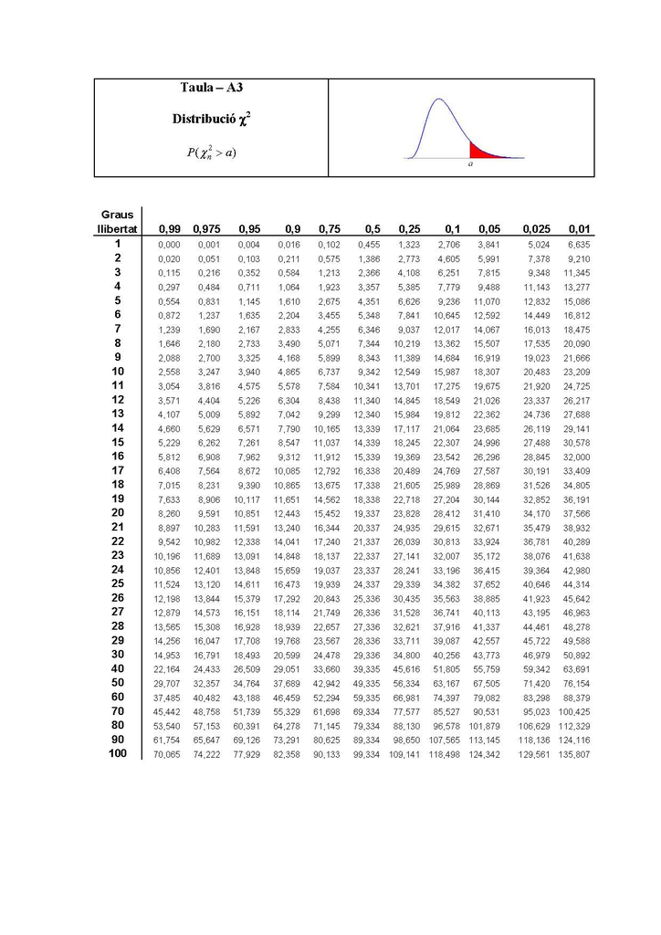

# Summary

For a random sample $X_1,...X_n$ of size $n$, from a ransom variable $X$ with $E(X)=\mu_X$ y $V(X)=\sigma^2_X$ we have the following random variables:

- $Y=\sum_{j=1..n} X_j$ (sample sum)
- $\bar{X}=\frac{1}{n} \sum_{j=1..n} X_j$ (sample mean)
- $S^2=\frac{1}{n-1}\sum_{i=1}^n (X_i-\bar{X})^2$ (sample variance)

Each time that we take one sample os size $n$, these variables take different values ($y$, $\bar{x}$, $s^2$).

In general, no matter how $X$ distributes:

- $E(Y)=n\cdot \mu_X$ y $V(Y)=n\cdot \sigma^2_X$
- $E(\bar{X})=\mu_X$ y $V(\bar{X})=\frac{\sigma^2_X}{n}$
- $E(S^2)=\sigma^2_X$

However, if $X \hookrightarrow N(\mu_X, \sigma_X^2)$ then

- $Y \hookrightarrow N(n\cdot \mu_X, n\cdot \sigma_X^2)$ (which we can also use when $n>30$ no matter the distribution of $X$: CLT)
- $\bar{X} \hookrightarrow N(\mu_X, \sigma_X^2/n)$ (which we can also use when $n>30$ no matter the distribution of $X$: CLT)
- $\frac{S^2(n-1)}{\sigma^2} \hookrightarrow \chi^2(n-1)$

# Summary

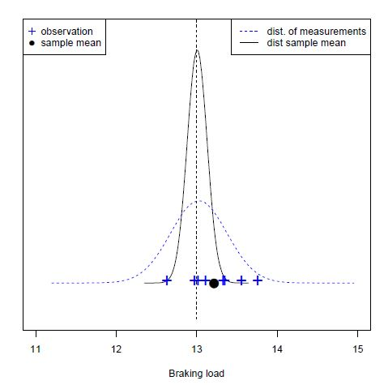

# Resumen

**Definition**

Given a ransom sample $X_1,...X_n$ an **estadistic** is any function of the variables and with real value: $f(X_1,...X_n)$

- $\bar{X}=\frac{1}{N} \sum_{j=1..N} X_j$
- $S^2=\frac{1}{n-1}\sum_{i=1}^n (X_i-\bar{X})^2$
- $\max{X_1, X_n}$

are estatistics

- $\bar{X}$ is an estatistic, **unbiased** estimator of $\mu_X$ bacause $E(\bar{X})=\mu_X$
- $S^2$ s an estatistic, **unbiased** estimator of $\sigma_X^2$ because $E(S^2)=\sigma_X^2$

If the variance of the estatitics tend to zero when $n \rightarrow \infty$, then we say that they are **consistent** estatistics.

# Ejercicio

Una cierta componente es crítica en la operación de un sistema eléctrico y debe ser reparada inmediatamente si falla. La vida media de la componente es de 100 horas y su desviación estándar es 30 horas.

1. Si se toma una muestra de 50 componentes, ¿cuál es la probabilidad de que la media muestral no diﬁera de la media poblacional más de 1 hora?
2. ¿Cuántas componentes deben tenerse preparadas en stock para que la probabilidad de que el sistema funcione durante 2750 horas consecutivas sea 0.95? (asume que la duración de la componente es una variable normal)